# Assignment 2: Hand Gesture Recognition [50 Pt]

This assignment will be completed in two parts. In Part A you will gain experience gathering your own data set (specifically images of hand gestures), and understand the challenges involved in the data cleaning process. In Part B you will train a convolutional neural network to make classifications on different hand gestures. By the end of this assignment, you should be able to:

1. Generate and preprocess your own data
2. Load and split data for training, validation and testing
3. Train a Convolutional Neural Network
4. Apply transfer learning to improve your model

Note that for this assignment we will not be providing you with any starter code. You should be able to take the sample code provided in the preparation sample code, previous assignment, and lectures and modify it accordingly to complete the tasks outlined below.

*This assignment is based on an assignment developed by Prof. Lisa Zhang.*

### What to submit

**Submission for Part A:**  
Submit a zip file containing your images. Three images each of American Sign Language gestures for letters A - I (total of 27 images). You will be required to clean the images before submitting them. Details are provided under Part A of the handout.

Individual image file names should follow the convention of student-number_Alphabet_file-number.jpg (e.g. 100343434_A_1.jpg).

**Submission for Part B:**  
Submit an HTML file containing all your code, outputs, and write-up from parts A and B. You can produce a HTML file directly from Google Colab. The Colab instructions are provided at the end of this document.

**Do not submit any other files produced by your code.**

Include a link to your colab file in your submission.

Please use Google Colab to complete this assignment. If you want to use Jupyter Notebook, please complete the assignment and upload your Jupyter Notebook file to Google Colab for submission.

## Colab Link

Include a link to your colab file here and ensure the file can be accessed by the our teaching team.

```python
# TO BE COMPLETED

https://colab.research.google.com/drive/1UIOue0mOLvzL5Qmrwm3Gh9LjTN1eK3aP
```

# Part A. Data Collection [5pt]

So far, we have worked with data sets that have been collected, cleaned, and curated by machine learning researchers and practitioners. Datasets like MNIST and CIFAR are often used as toy examples, both by students and by researchers testing new machine learning models.

In the real world, getting a clean data set is never that easy. More than half the work in applying machine learning is finding, gathering, cleaning, and formatting your data set.

The purpose of this assignment is to help you gain experience gathering your own data set, and understand the challenges involved in the data cleaning process.

### American Sign Language

American Sign Language (ASL) is a complete, complex language that employs signs made by moving the hands combined with facial expressions and postures of the body. It is the primary language of many North Americans who are deaf and is one of several communication options used by people who are deaf or hard-of-hearing.

The hand gestures representing English alphabet are shown below. This assignment focuses on classifying a subset of these hand gesture images using convolutional neural networks. Specifically, given an image of a hand showing one of the letters A-I, we want to detect which letter is being represented.

[figure not shown]

### Generating Data

We will produce the images required to assess our models by ourselves. You are required to collect, clean and submit three images each of Americal Sign Language gestures for letters A - I (total of 27 images) Steps involved in data collection

1. Familiarize yourself with American Sign Language gestures for letters from A - I (9 letters).
2. Take three pictures at slightly different orientation for each letter gesture using your mobile phone.
- Ensure adequate lighting while you are capturing the images.
- Use a white wall as your background.
- Use your right hand to create gestures (for consistency).
- Keep your right hand fairly apart from your body and any other obstructions.
- Avoid having shadows on parts of your hand.
3. Transfer the images to your laptop for cleaning.

### Cleaning Data

To simplify the machine learning the task, we will standardize the training images. We will make sure that all our images are of the same size (224 x 224 pixels RGB), and have the hand in the center of the cropped regions.

You may use the following applications to crop and resize your images:

**Mac**

- Use Preview: – Holding down CMD + Shift will keep a square aspect ratio while selecting the hand area. – Resize to 224x224 pixels.

**Windows 10**

- Use Photos app to edit and crop the image and keep the aspect ratio a square.
- Use Paint to resize the image to the final image size of 224x224 pixels.

**Linux**

- You can use GIMP, imagemagick, or other tools of your choosing. You may also use online tools such as http://picresize.com All the above steps are illustrative only. You need not follow these steps but following these will ensure that you produce a good quality dataset. You will be judged based on the quality of the images alone. Please do not edit your photos in any other way. You should not need to change the aspect ratio of your image. You also should not digitally remove the background or shadows—instead, take photos with a white background and minimal shadows.

### Accepted Images

Images will be accepted and graded based on the criteria below

1. The final image should be size 224x224 pixels (RGB).
2. The file format should be a .jpg file.
3. The hand should be approximately centered on the frame.
4. The hand should not be obscured or cut off.
5. The photos follows the ASL gestures posted earlier.
6. The photos were not edited in any other way (e.g. no electronic removal of shadows or background).

### Submission

Submit a zip file containing your images. There should be a total of 27 images (3 for each category)

1. Individual image file names should follow the convention of student-number_Alphabet_file-number.jpg (e.g. 100343434_A_1.jpg)
2. Zip all the images together and name it with the following convention: last-name_student-number.zip (e.g. last-name_100343434.zip).
3. Submit the zipped folder.

[figure not shown]

# Part B. Building a CNN [45pt]

For this assignment, we are not going to give you any starter code. You will be writing a convolutional neural network from scratch. You are welcome to modify and combine code provided previously in the course (assignments, preparation code, lectures, etc.). You can also write your own code.

You may use the PyTorch documentation freely. You might also find online tutorials helpful. However, all code that you submit must be be your own. You cannot take a completed assignment and claim it as your own.

Make sure that your code is vectorized, and does not contain obvious inefficiencies (for example, unecessary for loops, or unnecessary calls to unsqueeze()). Ensure enough comments are included in the code so that your TA can understand what you are doing. It is your responsibility to show that you understand what you write.

**This is much more challenging and time-consuming than the previous assignments.** Make sure that you give yourself plenty of time by starting early.

## Part 1. Data Loading and Splitting [3pt EXPLORATORY]

Download the anonymized data provided on Quercus. Split the data into training, validation, and test sets.

Note: Data splitting is not as trivial in this assignment. We want our test set to closely resemble the setting in which our model will be used. In particular, our test set should contain hands that are never seen in training!

Explain how you split the data, either by describing what you did, or by showing the code that you used. Justify your choice of splitting strategy. How many training, validation, and test images do you have?

For loading the data, you can use plt.imread, or any other method that you choose. You may find torchvision.datasets.ImageFolder helpful. (see https://pytorch.org/vision/main/generated/torchvision.datasets.ImageFolder.html) )

```python
import os, zipfile, numpy as np
from pathlib import Path
import matplotlib.pyplot as plt
from PIL import Image
from sklearn.metrics import confusion_matrix
import seaborn as sns
import pandas as pd
import numpy as np
import time
import shutil

import torch
import torch.nn as nn
import torch.nn.functional as F
import torch.optim as optim

import torchvision
from torchvision import datasets, transforms
from torch.utils.data.sampler import SubsetRandomSampler
from torch.utils.data import DataLoader, random_split, Subset, Dataset
```

```python
# ======== part 1: Unzip and save the anonymized data files ========

ZIP_PATH = "/content/A2_Hand_Gesture_Dataset_revised.zip"
DATA_ROOT = Path("/content/asl_data")


seed = 999
BATCH_SIZE = 64


if DATA_ROOT.exists():
    shutil.rmtree(DATA_ROOT)
DATA_ROOT.mkdir(parents=True, exist_ok=True)

with zipfile.ZipFile(ZIP_PATH, "r") as z:
    z.extractall(DATA_ROOT)



# ======== part 2: read images & create claesses ========

samples = []
for p in DATA_ROOT.glob("*/*/*.jpg"):
    cls = p.parent.name
    samples.append((p, cls))


# create classes
classes = sorted({c for _, c in samples})
class_to_idx = {c: i for i, c in enumerate(classes)}
```

```python
# ======== part 3: Transfiormation ========

class ASLDataset(Dataset):
    def __init__(self, samples, classes, class_to_idx, img_size=224):
        self.samples = [(p, class_to_idx[c]) for p, c in samples]
        self.num_classes = len(class_to_idx)
        self.classes = classes
        self.img_size = img_size

    def __len__(self):
        return len(self.samples)

    def __getitem__(self, i):
        path, y_idx = self.samples[i]
        arr = plt.imread(str(path))                 # (224,224,3)
        if arr.ndim == 2:                           # grey handling
            arr = np.stack([arr] * 3, axis=-1)
        if arr.dtype != np.float32:
            arr = arr.astype(np.float32) / (255.0 if arr.max() > 1.0 else 1.0)

        # resize to 224×224
        img = Image.fromarray((arr * 255).astype(np.uint8))
        img = img.resize((self.img_size, self.img_size), Image.BILINEAR)
        arr = np.asarray(img).astype(np.float32) / 255.0

        x = torch.from_numpy(arr.transpose(2, 0, 1))  # -> (3,224,224), [0,1]

        # one-hot encoding of y
        y = torch.zeros(self.num_classes, dtype=torch.float32)
        y[y_idx] = 1.0
        return x, y



# ======== part 4: Split Data ========

def get_loaders_split_by_person(samples, class_to_idx, batch_size=64,
                                seed=seed, val_ratio=0.2, test_ratio=0.15,
                                shuffle_train=True):
    """
    Split into Train/Val/Test by person ID (filename prefix before the first underscore),
    and return DataLoaders.

    Args:
        samples: list of (Path, class_name)
        class_to_idx: dict {class_name: class_idx}
        batch_size: DataLoader batch size
        seed: RNG seed
        val_ratio: fraction of UNIQUE persons assigned to validation
        test_ratio: fraction of UNIQUE persons assigned to test
        shuffle_train: whether to shuffle the training DataLoader

    Returns:
        train_loader, val_loader, test_loader, split_meta (dict)
    """

    # 1) Derive person IDs from filenames: "<personID>_<class>_<sampleID>.jpg"
    persons = np.array([p.name.split('_', 1)[0] for p, _ in samples])
    uniq = np.unique(persons)


    # 2) Person-level split (disjoint persons across splits)
    rng = np.random.default_rng(seed)
    perm = rng.permutation(len(uniq))

    n_test = int(test_ratio * len(uniq))                          # 15% test data
    n_val  = int((1 - test_ratio) * val_ratio * len(uniq))        # 17% validation data (i.e. (1-0.15) * 0.2 = 0.17)
                                                                  # 68% training data
    test_persons = set(uniq[perm[:n_test]])
    val_persons  = set(uniq[perm[n_test:n_test + n_val]])
    train_persons = set(uniq[perm[n_test + n_val:]])

    idx = np.arange(len(samples))
    train_idx = idx[np.isin(persons, list(train_persons))]
    val_idx   = idx[np.isin(persons, list(val_persons))]
    test_idx  = idx[np.isin(persons, list(test_persons))]


    # 3) Build Datasets and DataLoaders
    full_ds  = ASLDataset(samples, classes, class_to_idx)   # defined earlier: one-hot + plt.imread
    train_ds = Subset(full_ds, train_idx.tolist())
    val_ds   = Subset(full_ds,   val_idx.tolist())
    test_ds  = Subset(full_ds,  test_idx.tolist())


    train_loader = DataLoader(train_ds, batch_size=batch_size, shuffle=shuffle_train)
    val_loader   = DataLoader(val_ds,   batch_size=batch_size, shuffle=False)
    test_loader  = DataLoader(test_ds,  batch_size=batch_size, shuffle=False)


    # 4) Metadata for reporting/reproducibility
    split_meta = {
        "num_images": {
            "train": len(train_ds), "val": len(val_ds), "test": len(test_ds)
        },
        "num_persons": {
            "train": int(len(train_persons)), "val": int(len(val_persons)), "test": int(len(test_persons))
        },
        "ratios": {"val_ratio": val_ratio, "test_ratio": test_ratio},
        "seed": seed
    }
    return train_loader, val_loader, test_loader, split_meta




# ======== part 5: Plot Distribution of Split Datasets ========

def labels_from_subset(loader):
  '''
  Get labels from a subset for plotting distribution of classes
  '''
  base_subset = loader.dataset          # DataLoader -> Subset
  ds = base_subset.dataset              # Subset -> ASLDataset
  idxs = base_subset.indices            # idx to ds.samples
  y_idx = np.array([ds.samples[i][1] for i in idxs], dtype=int)  # class idx
  classes = np.array(ds.classes)        # class list

  return y_idx



def plot_dist(y, classes, title):
    """
    Plot distribution of classes with count labels on bars.
    """

    y = np.asarray(y)
    counts = np.bincount(y, minlength=len(classes))

    fig, ax = plt.subplots()
    ax.set_title(title)
    x = np.arange(len(classes))
    bars = ax.bar(x, counts)
    ax.set_xticks(x)
    ax.set_xticklabels(classes, rotation=45, ha='right')
    ax.set_ylabel("Example Count")
    fig.tight_layout()

    ax.bar_label(bars, padding=2)
    plt.show()
    return counts


def balance_report(counts, split_name):
  '''
  Use min/max ratio to determine if dataset is balanced or imbalanced.
  '''

  ratio = counts.max() / counts.min()
  print(f"{split_name}: min={counts.min()}, max={counts.max()}, imbalance_ratio={ratio:.2f} "
        f"-> {'Imbalanced' if ratio > 1.5 else 'Balanced-ish'}")
```

```
Classes: ['A', 'B', 'C', 'D', 'E', 'F', 'G', 'H', 'I']
Split sizes: {'train': 1708, 'val': 402, 'test': 322}
Persons per split: {'train': 64, 'val': 15, 'test': 13}
```

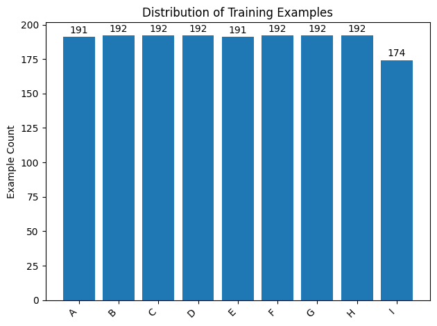

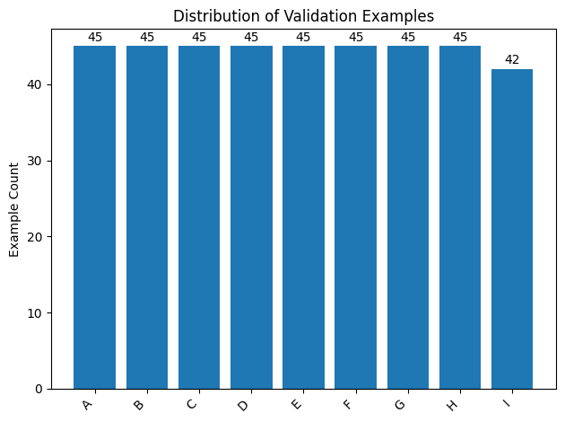

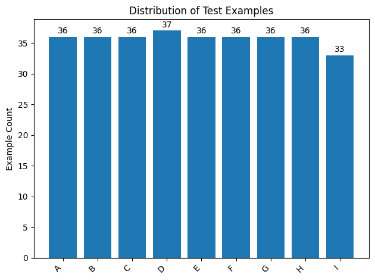

```
Train: min=174, max=192, imbalance_ratio=1.10 -> Balanced-ish
Val: min=42, max=45, imbalance_ratio=1.07 -> Balanced-ish
Test: min=33, max=37, imbalance_ratio=1.12 -> Balanced-ish
```

```python
train_loader, val_loader, test_loader, split_meta = get_loaders_split_by_person(samples, class_to_idx)

# quick stats
print("Classes:", classes)
print("Split sizes:", split_meta["num_images"])
print("Persons per split:", split_meta["num_persons"])

y_train = labels_from_subset(train_loader)
y_val = labels_from_subset(val_loader)
y_test = labels_from_subset(test_loader)

# Plot class distribution for 3 datasets
counts_train = plot_dist(y_train, classes, "Distribution of Training Examples")
counts_val   = plot_dist(y_val,   classes, "Distribution of Validation Examples")
counts_test  = plot_dist(y_test,  classes, "Distribution of Test Examples")


# Get the min/max ratios for 3 datasets to see if they are balanced
balance_report(counts_train, "Train")
balance_report(counts_val,   "Val")
balance_report(counts_test,  "Test")
```

```python
'''
I split people-disjointly, because I don't want to test hand that are already in either training or testing datasets.

I split 15% of people's hand images as test data, 17% as the validation data, and the rest as training data.
'''
```

## Part 2. Model Building and Sanity Checking [5pt]

### Part (i) Convolutional Network [2pt MODEL]

Build a convolutional neural network model that takes the (224x224 RGB) image as input, and predicts the gesture letter. Your model should be a subclass of nn.Module. Explain your choice of neural network architecture: how many layers did you choose? What types of layers did you use? Were they fully-connected or convolutional? What about other decisions like pooling layers, activation functions, number of channels / hidden units?

```python
# TO BE COMPLETED

class cnn(nn.Module):
    def __init__(self, num_classes=9, p=0.2):
      super(cnn, self).__init__()
      self.name = "cnn"
      self.conv1 = nn.Conv2d(3, 6, kernel_size=3, padding=0, bias=False)      # 224 -> 222 -> pool -> 111
      self.bn1 = nn.BatchNorm2d(6)
      self.conv2 = nn.Conv2d(6, 16, kernel_size=3, padding=0, bias=False)     # 111 -> 109 -> pool -> 54
      self.bn2 = nn.BatchNorm2d(16)
      self.conv3 = nn.Conv2d(16, 32, kernel_size=3, padding=0, bias=False)    # 54 -> 52 -> pool -> 26
      self.bn3 = nn.BatchNorm2d(32)
      self.conv4 = nn.Conv2d(32, 64, kernel_size=3, padding=0, bias=False)    # 26 -> 24 -> pool -> 12
      self.bn4 = nn.BatchNorm2d(64)
      self.conv5 = nn.Conv2d(64, 128, kernel_size=3, padding=0, bias=False)    # 12 -> 10 -> pool -> 5
      self.bn5 = nn.BatchNorm2d(128)
      self.pool = nn.MaxPool2d(2,2)
      self.dropout = nn.Dropout(p)
      self.fc = nn.Linear(128 * 5 * 5, num_classes)


    def forward(self, x):
      x = self.pool(F.relu(self.bn1(self.conv1(x))))
      x = self.pool(F.relu(self.bn2(self.conv2(x))))
      x = self.pool(F.relu(self.bn3(self.conv3(x))))
      x = self.pool(F.relu(self.bn4(self.conv4(x))))
      x = self.pool(F.relu(self.bn5(self.conv5(x))))
      x = x.view(-1, 128 * 5 * 5)
      logits = self.dropout(self.fc(x))

      return logits
```

```python
'''
how many layers did you choose?
 --> I have 5 convolutional layers and 1 fully connected layer.


Explain your choice of neural network architecture:
 --> I select 5 convolutional layers to lower the parameters, then followed with only 1 fully connected layer to preventing overfitting.

What types of layers did you use?
  conv1 -> bacthnorm1 -> relu -> MaxPolling ->
  conv2 -> bacthnorm2 -> relu -> MaxPolling ->
  conv3 -> bacthnorm3 -> relu -> MaxPolling ->
  conv4 -> bacthnorm4 -> relu -> MaxPolling ->
  conv5 -> bacthnorm5 -> relu -> MaxPolling -> fc

Were they fully-connected or convolutional?
 --> All 5 convolution layers are in former part for feature extraction, then followed with a fully connected layer

What about other decisions like pooling layers, activation functions, number of channels / hidden units?
 --> MaxPooling for avoinding overfitting and parameters number reductions
 --> ReLU for non-linearity

'''
```

```python
cnn = cnn()
```

### Part (ii) Training Code [2pt MODEL]

Write code that trains your neural network given some training data. Your training code should make it easy to tweak the usual hyperparameters, like batch size, learning rate, and the model object itself. Make sure that you are checkpointing your models from time to time (the frequency is up to you). Explain your choice of loss function and optimizer.

```python
def evaluate(net, loader, criterion, device=None):
    """Evaluate the network on a given dataset."""

    net.eval()
    if device is None:
        device = next(net.parameters()).device

    total_loss = 0.0
    total_err = 0
    total_samples = 0

    with torch.no_grad():
        for inputs, labels_onehot in loader:  # labels are one-hot from our dataset

            targets = labels_onehot.argmax(dim=1)  # one-hot -> class idx
            outputs = net(inputs)

            # Compute loss
            loss = criterion(outputs, targets)

            pred = outputs.argmax(dim=1)
            total_err += (pred != targets).sum().item()
            total_loss += loss.item()
            total_samples += targets.size(0)

    err = total_err / total_samples
    avg_loss = total_loss / max(1, len(loader))

    return err, avg_loss




def get_model_name(name, batch_size, learning_rate, epoch,
                   weight_decay, dropout_p):
    """Generate a safe checkpoint path and ensure directory exists."""

    fname = "model_{name}_bs{batch_size}_lr{learning_rate}_wd{weight_decay}_dp{dropout_p}_epoch{epoch}".format(
        name=name, batch_size=batch_size, learning_rate=learning_rate,
        weight_decay=weight_decay, dropout_p=dropout_p, epoch=epoch+1)
    return fname




def _get_num_classes(loader):
  """For handling Small datasets without all classes"""
  ds = loader.dataset

  while isinstance(ds, Subset):
      ds = ds.dataset
  if hasattr(ds, "num_classes"): return int(ds.num_classes)
  if hasattr(ds, "classes"):     return len(ds.classes)
  raise ValueError("Cannot infer num_classes from dataset.")
```

```python
def train_net_cnn(net, train_loader, val_loader, test_loader, seed=seed,
                  num_epochs=20, learning_rate=1e-3, weight_decay=0,
                  dp=0, batch_size=BATCH_SIZE, device=None):

    # infer classes from the given loader
    num_classes = _get_num_classes(train_loader)

    # instantiate model (if a class was passed)
    net = cnn(num_classes=num_classes, p=dp) if isinstance(net, type) else net

    # device
    if device is None:
        device = "cuda" if torch.cuda.is_available() else "cpu"
    net = net.to(device)
    net.train()

    torch.manual_seed(seed)
    criterion = nn.CrossEntropyLoss()
    optimizer = optim.Adam(net.parameters(), lr=learning_rate, weight_decay=weight_decay)

    train_err = np.zeros(num_epochs); train_loss = np.zeros(num_epochs)
    val_err   = np.zeros(num_epochs); val_loss   = np.zeros(num_epochs)

    t0 = time.time()
    for epoch in range(num_epochs):
        net.train()
        tot_loss, tot_err, tot_n = 0.0, 0, 0

        # training
        for x, y_onehot in train_loader:
            x = x.to(device)
            y = y_onehot.argmax(1).long().to(device)

            optimizer.zero_grad()
            logits = net(x)
            loss = criterion(logits, y)
            loss.backward()
            optimizer.step()

            pred = logits.argmax(1)
            tot_err  += (pred != y).sum().item()
            tot_loss += loss.item()
            tot_n    += y.size(0)

        train_err[epoch]  = tot_err / tot_n
        train_loss[epoch] = tot_loss / max(1, len(train_loader))

        # validation
        net.eval(); tl, te, tn = 0.0, 0, 0
        with torch.no_grad():
            for x, y_onehot in val_loader:
                x = x.to(device)
                y = y_onehot.argmax(1).long().to(device)
                out = net(x)
                l = criterion(out, y)
                p = out.argmax(1)
                te += (p != y).sum().item()
                tl += l.item()
                tn += y.size(0)
        val_err[epoch]  = te / tn
        val_loss[epoch] = tl / max(1, len(val_loader))

        print(f"Epoch {epoch+1:02d} | train err {train_err[epoch]:.4f} loss {train_loss[epoch]:.4f} || "
              f"val err {val_err[epoch]:.4f} loss {val_loss[epoch]:.4f}")

        # Save the current model (checkpoint) to a file
        model_path = get_model_name(net.name, batch_size, learning_rate, epoch, weight_decay, dp)
        torch.save(net.state_dict(), model_path)



            # Write the train/test loss/error into CSV files for plotting later
    epochs = np.arange(1, num_epochs + 1)
    np.savetxt(f"{model_path}_train_err.csv", train_err)
    np.savetxt(f"{model_path}_train_loss.csv", train_loss)
    np.savetxt(f"{model_path}_val_err.csv", val_err)
    np.savetxt(f"{model_path}_val_loss.csv", val_loss)
    print("Finished Training. Elapsed: %.1fs" % (time.time() - t0))

    return {"train_err": train_err, "train_loss": train_loss,
            "val_err": val_err, "val_loss": val_loss}
```

```python
model_default = train_net_cnn(cnn, train_loader, val_loader, test_loader)
```

```
Epoch 01 | train err 0.4701 loss 1.3837 || val err 0.8881 loss 2.1478
Epoch 02 | train err 0.2032 loss 0.6753 || val err 0.3905 loss 1.0417
Epoch 03 | train err 0.1323 loss 0.4438 || val err 0.2313 loss 0.7215
Epoch 04 | train err 0.0831 loss 0.2936 || val err 0.2438 loss 0.7562
Epoch 05 | train err 0.0597 loss 0.2273 || val err 0.2388 loss 0.8119
Epoch 06 | train err 0.0234 loss 0.1307 || val err 0.2015 loss 0.7030
Epoch 07 | train err 0.0053 loss 0.0742 || val err 0.1915 loss 0.6586
Epoch 08 | train err 0.0018 loss 0.0464 || val err 0.1990 loss 0.6230
Epoch 09 | train err 0.0000 loss 0.0257 || val err 0.1915 loss 0.6827
Epoch 10 | train err 0.0000 loss 0.0161 || val err 0.1891 loss 0.6791
Epoch 11 | train err 0.0000 loss 0.0120 || val err 0.1841 loss 0.7005
Epoch 12 | train err 0.0000 loss 0.0092 || val err 0.1915 loss 0.6654
Epoch 13 | train err 0.0000 loss 0.0077 || val err 0.1866 loss 0.6792
Epoch 14 | train err 0.0000 loss 0.0066 || val err 0.1915 loss 0.6897
Epoch 15 | train err 0.0000 loss 0.0055 || val err 0.1891 loss 0.6967
Epoch 16 | train err 0.0000 loss 0.0047 || val err 0.1915 loss 0.7126
Epoch 17 | train err 0.0000 loss 0.0042 || val err 0.1940 loss 0.7121
Epoch 18 | train err 0.0000 loss 0.0037 || val err 0.1965 loss 0.7041
Epoch 19 | train err 0.0000 loss 0.0033 || val err 0.2040 loss 0.7555
Epoch 20 | train err 0.0000 loss 0.0030 || val err 0.1915 loss 0.7095
Finished Training. Elapsed: 1003.2s
```

```python
'''
I choose Cross Entropy Loss because it's good for classification problem, and embeds with softmax that makes my model lighter

I choose Adam Optimnizer because it's friendly to small dataset and small/medium batch size, which will converge quicklier and more stable.
'''
```